# Apuntes · Complejos · Sesión 1 — Los números complejos y su plano

> La construcción rigurosa (pares ordenados, sin misticismo), las propiedades del conjugado y el módulo demostradas, la fórmula del inverso, el plano de Argand, y la prueba completa de que ℂ no admite un orden compatible. Ejercicios y ampliación al final.

## 1.1 La construcción

**Definición 2.1.1.** Un **número complejo** es un par ordenado $(a,b) \in \mathbb{R} \times \mathbb{R}$ (producto cartesiano, M0). En el conjunto $\mathbb{C}$ de tales pares se definen:
$$(a,b) + (c,d) = (a+c,\; b+d), \qquad (a,b)\cdot(c,d) = (ac - bd,\; ad + bc).$$

**Proposición 2.1.2.** 1. Los pares de la forma $(a, 0)$ operan entre sí exactamente como los reales: $(a,0)+(c,0) = (a+c, 0)$ y $(a,0)(c,0) = (ac, 0)$. Identificamos $a \leftrightarrow (a,0)$: **$\mathbb{R}$ vive dentro de $\mathbb{C}$** respetando las operaciones. 2. Escribiendo $i = (0,1)$: $\;i^2 = (0,1)(0,1) = (0\cdot 0 - 1 \cdot 1,\; 0\cdot 1 + 1 \cdot 0) = (-1, 0) = -1$. 3. Todo par se escribe de **forma única** como $(a,b) = a + bi$ (la **forma binómica**), y las operaciones de 1.1 son las de “operar con la distributiva y sustituir $i^2 = -1$”.

*Demostración.* (1) y (2): cálculo directo con la Definición 2.1.1. (3) $(a,b) = (a,0) + (0,b) = (a,0) + (b,0)(0,1) = a + bi$; la unicidad es la de las componentes del par. Que las operaciones coinciden: expandir $(a+bi)(c+di)$ con distributiva e $i^2 = -1$ da $(ac - bd) + (ad + bc)i$ — la fórmula de 1.1. $\blacksquare$

> **El sentido del enfoque:** $i$ no es un ente misterioso que “haya que creerse”: es el par $(0,1)$, y $i^2 = -1$ es un **cálculo** (Proposición 2.1.2(2)). La fórmula del producto no es arbitraria: es la única compatible con la distributiva y con $i^2 = -1$ (eso dice la Proposición 2.1.2(3)). Las propiedades de anillo (asociativas, conmutativas, distributiva, neutros $0 = (0,0)$ y $1 = (1,0)$) se verifican mecánicamente desde 1.1 — ejercicio 6 hace una; las demás son idénticas.

## 1.2 Conjugado y módulo

**Definición 2.1.3.** Para $z = a + bi$: el **conjugado** $\bar z = a - bi$; el **módulo** $|z| = \sqrt{a^2 + b^2}$; la **parte real** $\mathrm{Re} z = a$ y la **imaginaria** $\mathrm{Im} z = b$ — *atención: $\mathrm{Im} z$ es el número real $b$, **no** $bi$; es el error más frecuente del tema*. Se dice que $z$ es **imaginario puro** cuando $\mathrm{Re} z = 0$, es decir, cuando $z = bi$ con $b \in \mathbb{R}$: son exactamente los puntos del eje vertical.

**Proposición 2.1.4 (propiedades del conjugado).** 1. $\overline{z + w} = \bar z + \bar w$ y $\overline{z \cdot w} = \bar z \cdot \bar w$ (conjugar respeta las operaciones). 2. $\bar{\bar z} = z$; $\;z + \bar z = 2\mathrm{Re} z$; $\;z - \bar z = 2i \mathrm{Im} z$. 3. $z = \bar z \iff z \in \mathbb{R}$.

*Demostración.* (1, producto — el menos obvio): con $z = a+bi$, $w = c+di$: $\overline{zw} = (ac-bd) - (ad+bc)i$, y $\bar z \bar w = (a-bi)(c-di) = (ac - bd) + (-ad - bc)i$ — coinciden. (Suma: inmediata.) (2) y (3): lectura directa de las definiciones. $\blacksquare$

**Proposición 2.1.5 (la identidad clave).** $\;z \cdot \bar z = |z|^2$ — un número **real** y $\ge 0$, nulo solo si $z = 0$.

*Demostración.* $(a+bi)(a-bi) = a^2 - (bi)^2 = a^2 + b^2$. Es suma de cuadrados reales: $\ge 0$, y $= 0$ solo con $a = b = 0$. $\blacksquare$

**Teorema 2.1.6 (división: $\mathbb{C}$ es un cuerpo).** Todo $z \neq 0$ tiene inverso:
$$z^{-1} = \frac{\bar z}{|z|^2}.$$

*Demostración.* $z \cdot \dfrac{\bar z}{|z|^2} = \dfrac{z \bar z}{|z|^2} = \dfrac{|z|^2}{|z|^2} = 1$ (legítimo: $|z|^2 \neq 0$ por 2.1.5). $\blacksquare$

> **Hilo de cuerpos, segunda parada:** $\mathbb{Z}/p\mathbb{Z}$ (Aritmética, finito) y ahora $\mathbb{C}$ — dos mundos donde todo no nulo se invierte. El nombre **cuerpo** se usa como etiqueta; la definición formal y su teoría llegan en Álgebra Lineal. **En la práctica:** dividir es multiplicar numerador y denominador por el conjugado del denominador — y la Proposición 2.1.5 es el porqué (vuelve real el denominador).

**Corolario 2.1.7.** $|z w| = |z| |w|$.

*Demostración.* $|zw|^2 = (zw)\overline{(zw)} = z \bar z\, w \bar w = |z|^2 |w|^2$ (usando la Proposición 2.1.4(1) y conmutatividad); raíces de no negativos. $\blacksquare$

## 1.3 El plano de Argand

La Definición 2.1.1 ya **es** la identificación: $a + bi$ es el punto $(a,b)$ del plano. Eje horizontal = reales; vertical = imaginarios puros.

- **Suma = paralelogramo:** componente a componente.
- **Módulo = distancia al origen** (Pitágoras escolar; $|z - w|$ = distancia entre los puntos — la teoría general de distancias, en el módulo de Geometría).
- **Conjugar = reflejar** respecto del eje real.
- El **producto** tiene lectura geométrica espectacular — Sesión 2.

[figure not shown]

Plano de Argand: el punto $z=a+bi$ en coordenadas $(a,b)$; la suma $z+w$ como cuarto vértice del paralelogramo de $z$ y $w$.

[figure not shown]

Conjugación como reflexión respecto del eje real: $z=a+bi$ y $\bar z=a-bi$ son simétricos, con $|z|=|\bar z|$.

## 1.4 $\mathbb{C}$ no puede ordenarse (el precio de la construcción)

**Proposición 2.1.8.** No existe en $\mathbb{C}$ un orden **total** compatible con las operaciones, es decir, un orden que cumpla **(T)** dados $a, b$, o bien $a < b$, o bien $a = b$, o bien $b < a$; **(O1)** $a < b \Rightarrow a + c < b + c$; y **(O2)** $0 < a,\, 0 < b \Rightarrow 0 < ab$.

*Demostración (por contradicción, M0).* Supóngase que existe. *Paso 1: todo cuadrado de un elemento no nulo es positivo.* Por (T), un $x \neq 0$ cae en uno de dos casos. Si $x > 0$, entonces $x \cdot x > 0$ por (O2). Si $x < 0$, sumando $-x$ a ambos lados por (O1): $0 < -x$, luego $(-x)(-x) > 0$ por (O2), y $(-x)(-x) = x^2$. En particular $1 = 1^2 > 0$, y sumando $-1$ por (O1): $-1 < 0$. *Paso 2:* $i \neq 0$, luego $i^2 > 0$ por el paso 1 — pero $i^2 = -1 < 0$. Contradicción. $\blacksquare$

> Se gana mucho (todas las ecuaciones, S3) y se pierde algo real: en $\mathbb{C}$ no tiene sentido “$z < w$”. Esta carencia reaparecerá: la geometría **métrica** (módulo de Geometría) necesita un cuerpo ordenado, y por eso vive en $\mathbb{R}$ y no en $\mathbb{C}$.

## Ejercicios

1. ★ Calcula $(2+3i)(1-2i)$, $\;\dfrac{3+4i}{1-2i}$ y $\dfrac{1}{i}$ — las divisiones **vía conjugado**, indicando en cada una dónde actúa la Proposición 2.1.5.
2. ★ Sitúa en el plano: $z = 2 + i$, $\bar z$, $-z$, $iz$ y $z + (1 - 2i)$ (este último con su paralelogramo). ¿Qué le hace geométricamente a $z$ cada operación?
3. ★ Resuelve $z^2 - 4z + 13 = 0$ y comprueba las dos soluciones. Observa: son conjugadas — ¿casualidad? (Volverá en la S3.)
4. Demuestra las propiedades 2.1.4(2) y 2.1.4(3) desde las definiciones.
5. Demuestra: $|\bar z| = |z|$, y $|z| = 0 \iff z = 0$.
6. Verifica la **asociatividad del producto** desde la Definición 2.1.1 para tres pares genéricos (mecánico pero instructivo: el rigor de la construcción tiene este precio una sola vez).
7. Demuestra que $\mathrm{Re}(z) \le |z|$ y $|z + w| \le |z| + |w|$. *(Pista para la segunda: $|z+w|^2 = (z+w)(\bar z + \bar w)$, expandir y usar la primera con $z\bar w$.)*
8. **(Contrafactual estructural, guiado.)** Reproduce la prueba de la Proposición 2.1.8 rellenando cada paso, y señala exactamente qué axioma del orden —(T), (O1) u (O2)— se usa en cada línea.

## Ampliación y referencias

> **Ampliación (la historia verdadera).** Los complejos no nacieron de $x^2 + 1 = 0$ (esa ecuación se despachaba con “no hay solución”) sino de las **cúbicas**: la fórmula de Cardano (s. XVI), aplicada a cúbicas con tres raíces reales, obligaba a pasar por raíces cuadradas de negativos *en pasos intermedios* — Bombelli descubrió que, calculando con ellas formalmente, los resultados reales correctos emergían. Los complejos entraron en la matemática **porque funcionaban**, dos siglos antes de que Hamilton diera (en 1835) la construcción por pares de la Definición 2.1.1. Véase Needham, *Visual Complex Analysis*, cap. 1.

> **Referencias.** Construcción y operaciones: Hernández, *Álgebra y geometría*; Childs. Visión geométrica (toda la del módulo): Needham, cap. 1 — la referencia estrella.

# Apuntes · Complejos · Sesión 2 — Forma polar: multiplicar es girar

> El teorema del producto en polar con su prueba, la lectura geométrica completa, De Moivre demostrado por inducción (con el caso de exponentes negativos), y la notación exponencial con su estatus discutido honestamente. Ejercicios y ampliación al final.

## 2.1 La forma polar

**Definición 2.2.1.** Para $z = a + bi \neq 0$: su **módulo** es $r = |z|$ y un **argumento** es cualquier ángulo $\theta$ con
$$a = r\cos\theta, \qquad b = r\mathrm{sen}\theta, \qquad \text{es decir,} \qquad z = r(\cos\theta + i \mathrm{sen}\theta).$$

[figure not shown]

Forma polar: el módulo $r=|z|$ es la distancia al origen y el argumento $\theta$ el ángulo con el eje real; $a=r\cos\theta$, $b=r\sin\theta$.

**Proposición 2.2.2 (el argumento, salvo vueltas).** Todo $z \neq 0$ tiene argumento, y dos argumentos de $z$ difieren en un **múltiplo entero de $2\pi$**. El representante en $(-\pi, \pi]$ se llama **argumento principal**.

*Demostración.* Existencia: el punto $(a/r,\, b/r)$ está en la circunferencia unidad, y todo punto de ella es $(\cos\theta, \mathrm{sen}\theta)$ para algún $\theta$ (trigonometría). Si $\theta, \theta'$ son argumentos del mismo $z$: $\cos\theta = \cos\theta'$ y $\mathrm{sen}\theta = \mathrm{sen}\theta'$ a la vez fuerzan $\theta - \theta' \in 2\pi\mathbb{Z}$. $\blacksquare$

[figure not shown]

El argumento está definido salvo múltiplos de $2\pi$: $\theta$, $\theta+2\pi$, $\theta-2\pi$ señalan el mismo punto. El representante en $(-\pi,\pi]$ es el argumento principal.

> **Este “salvo $2\pi$” no es letra pequeña:** es exactamente el mecanismo que en la Sesión 3 hará brotar las $n$ raíces $n$-ésimas. Conviene mirarlo con respeto desde ya.

**Método 2.2.3 (traducción, con los cuadrantes vigilados).** De polar a binómica no hay misterio: $a = r\cos\theta$, $b = r\mathrm{sen}\theta$. El cuidado está en el sentido inverso.

*De binómica a polar.* El módulo es directo, $r = \sqrt{a^2+b^2}$. El argumento sale de $\tan\theta = b/a$, **pero $\arctan$ no basta**: la función $\arctan$ devuelve siempre un ángulo en $(-\tfrac{\pi}{2}, \tfrac{\pi}{2})$, es decir, **solo sabe ver los cuadrantes I y IV** (los de $a>0$). Si el punto está a la izquierda del eje imaginario ($a<0$), $\arctan(b/a)$ apunta al complejo **diametralmente opuesto** —el de argumento $\theta\pm\pi$— porque $\tan$ no distingue un ángulo de su opuesto por el origen. Hay que corregir según los signos de $(a,b)$. Tomando el argumento principal en $(-\pi,\pi]$:

| Signo de $(a,b)$ | Cuadrante / eje | Argumento principal $\theta$ |
| --- | --- | --- |
| $a>0$ (cualquier $b$) | I y IV | $\arctan(b/a)$ |
| $a<0,\ b\ge 0$ | II | $\arctan(b/a) + \pi$ |
| $a<0,\ b<0$ | III | $\arctan(b/a) - \pi$ |
| $a=0,\ b>0$ | eje $+i$ | $+\pi/2$ |
| $a=0,\ b<0$ | eje $-i$ | $-\pi/2$ |

*(El criterio del $\pm\pi$ en la fila $a<0$ es solo “elegir el signo que cae dentro de $(-\pi,\pi]$”; sumar $\pi$ si $b\ge 0$, restarlo si $b<0$. Es lo que automatiza la función `atan2(b, a)` de calculadoras y lenguajes.)*

*Ejemplos del error clásico.* (i) $z = -1 - i$: $\tan\theta = 1$, pero está en el **tercer** cuadrante, así que $\theta = \arctan(1) - \pi = \tfrac{\pi}{4} - \pi = -\tfrac{3\pi}{4}$ —**no** $\pi/4$, que sería $1+i$. (ii) $z = -1 + i$: mismo $|\tan\theta|$, segundo cuadrante: $\theta = \arctan(-1) + \pi = -\tfrac{\pi}{4} + \pi = \tfrac{3\pi}{4}$. Los dos comparten $\tan\theta=\pm1$ con puntos del primer/cuarto cuadrante; el dibujo desambigua siempre: **mira en qué cuadrante cae $(a,b)$ antes de fijar el ángulo.**

[figure not shown]

$\arctan(b/a)$ da el argumento correcto solo si $a\gt 0$ (cuadrantes I y IV); en II y III hay que sumar o restar $\pi$ (aquí $z=-1+i$).

## 2.2 El teorema: multiplicar es girar

**Teorema 2.2.4 (producto en polar).** Si $z_1 = r_1(\cos\alpha + i\mathrm{sen}\alpha)$ y $z_2 = r_2(\cos\beta + i\mathrm{sen}\beta)$:
$$z_1 z_2 = r_1 r_2\big(\cos(\alpha + \beta) + i \mathrm{sen}(\alpha+\beta)\big).$$
**Los módulos se multiplican y los argumentos se suman.**

*Demostración.* Multiplicando en binómica:
$$z_1 z_2 = r_1 r_2\big[(\cos\alpha\cos\beta - \mathrm{sen}\alpha\mathrm{sen}\beta) + i(\cos\alpha\mathrm{sen}\beta + \mathrm{sen}\alpha\cos\beta)\big],$$
y los dos paréntesis son, exactamente, las fórmulas de la **suma de ángulos**: $\cos(\alpha+\beta)$ y $\mathrm{sen}(\alpha+\beta)$. $\blacksquare$

**Lectura geométrica (la joya).** Multiplicar por $z = r e^{i\theta}$ transforma el plano **girándolo** un ángulo $\theta$ y **escalándolo** por $r$. Casos que lo iluminan:

- Multiplicar por $i$ (módulo 1, argumento $\pi/2$): **giro de 90°**. Y entonces $i^2 = -1$ deja de ser una rareza: **dos giros de 90° son media vuelta**, y media vuelta es multiplicar por $-1$. La ecuación “imposible” de la S1 era geometría evidente. *(Con el estatus claro: esto **no es una demostración nueva** de $i^2 = -1$. La lectura “multiplicar por $i$ es girar 90°” se dedujo del Teorema 2.2.4, que se probó multiplicando en binómica — donde $i^2 = -1$ ya estaba dentro. Es la misma verdad, vista por fin de una forma que se recuerda.)*
- Por un real positivo: solo escala. Por $-1$: media vuelta. Por $\bar z / |z|^2$ (el inverso, Teorema 2.1.6): girar $-\theta$ y escalar $1/r$ — **deshacer**.

[figure not shown]

Multiplicar por $z^{-1}$ deshace lo que hace $z$: si $z$ gira $\theta$ y escala por $r$, entonces $z^{-1}$ gira $-\theta$ y escala por $1/r$, devolviendo $zw$ a $w$.

[interactive chart not shown]

Multiplicar por un complejo fijo $z=r\,e^{i\theta}$ transforma $w$ en $zw$ girando un ángulo $\theta$ y escalando por $r$; casos $z=i$ (90°), $z=-1$ (media vuelta), $z=z^{-1}$ (deshacer).

**El conjugado en polar, explícito.** Conjugar era cambiar el signo de la parte imaginaria; en polar es **cambiar el ángulo por su opuesto**, y basta escribirlo usando $\cos(-\theta) = \cos\theta$ y $\mathrm{sen}(-\theta) = -\mathrm{sen}\theta$:
$$\bar z = r\big(\cos(-\theta) + i\,\mathrm{sen}(-\theta)\big) = r(\cos\theta - i\,\mathrm{sen}\theta), \qquad \text{es decir}\qquad \overline{r e^{i\theta}} = r e^{-i\theta}.$$
Mismo módulo, argumento opuesto: el espejo sobre el eje real de la S1, ahora en una fórmula. Y dividiendo por $|z|^2 = r^2$ cae el inverso sin cuentas nuevas:
$$z^{-1} = \frac{\bar z}{|z|^2} = \frac{1}{r}(\cos\theta - i\,\mathrm{sen}\theta) = \frac{1}{r}e^{-i\theta}.$$

> **El $-\theta$ es *un* argumento, no todavía *el* argumento principal.** $\arg(z^{-1}) = -\theta$ vale **salvo $2\pi$** (Proposición 2.2.2), y el representante que pide el convenio vive en $(-\pi, \pi]$. Cuando $\theta = \pi$ —o sea, $z$ real negativo— el candidato $-\theta = -\pi$ **se sale del intervalo por el lado abierto**, y hay que sumarle $2\pi$: el argumento principal del inverso vuelve a ser $\boxed{\pi}$, no $-\pi$. Y tiene que ser así, porque el inverso de un real negativo es real negativo: $(-r)^{-1} = -1/r$, que sigue estando en el semieje de $\pi$. Es el único ángulo del intervalo sin pareja simétrica, precisamente por ser el extremo que sí se incluye.

> *Mención hacia delante:* “girar y escalar el plano” es el prototipo de las transformaciones que el módulo de Álgebra Lineal estudiará en general; este ejemplo os esperará allí.

## 2.3 De Moivre

**Teorema 2.2.5 (De Moivre).** Para todo $n \in \mathbb{Z}$ y $z = r(\cos\theta + i\mathrm{sen}\theta) \neq 0$:
$$z^n = r^n\big(\cos(n\theta) + i\mathrm{sen}(n\theta)\big).$$

*Demostración.* **$n \ge 1$, por inducción (M0):** el caso $n = 1$ es la definición; el paso $n \to n+1$ es el Teorema 2.2.4 aplicado a $z^n \cdot z$ (módulos $r^n \cdot r$, argumentos $n\theta + \theta$). **$n = 0$:** ambos miembros valen $1$. **$n < 0$:** escribiendo $n = -m$ con $m > 0$, $z^{-m} = (z^m)^{-1}$, y el inverso invierte el módulo y cambia el signo del argumento (lectura geométrica del Teorema 2.1.6, comprobada en el ejercicio 5): módulo $r^{-m}$, argumento $-m\theta$. $\blacksquare$

**Ejemplo 2.2.6.** $(1+i)^{10}$: en polar, $1 + i = \sqrt{2}\, e^{i\pi/4}$; De Moivre: $(\sqrt 2)^{10} e^{i\,10\pi/4} = 32\, e^{i 5\pi/2} = 32\, e^{i\pi/2} = 32 i$. (Reduciendo el argumento módulo $2\pi$ — otra vez el convenio.) Sin binomio de Newton, sin sufrimiento.

## 2.4 La notación exponencial (y su estatus, con honestidad)

**Definición-notación 2.2.7 (fórmula de Euler).** Se escribe
$$e^{i\theta} := \cos\theta + i\mathrm{sen}\theta,$$
de modo que todo $z \neq 0$ es $z = r e^{i\theta}$, y el Teorema 2.2.4 se convierte en la **regla de los exponentes**: $e^{i\alpha} e^{i\beta} = e^{i(\alpha+\beta)}$, y De Moivre en $(e^{i\theta})^n = e^{in\theta}$.

**La identidad de Euler, que aquí no cuesta nada.** Evaluando la notación 2.2.7 en $\theta = \pi$: $e^{i\pi} = \cos\pi + i\,\mathrm{sen}\pi = -1$, es decir
$$e^{i\pi} + 1 = 0.$$
Cinco constantes fundamentales en una línea. Conviene ver **por qué es trivial aquí**: no se ha demostrado nada: se ha sustituido $\theta = \pi$ en una definición. Toda la sustancia está en que la notación merezca el símbolo exponencial, y eso es lo que discute el recuadro siguiente.

> **El estatus, sin trampa:** a este nivel, $e^{i\theta}$ es una **notación** — extraordinariamente cómoda, y *merecedora* del símbolo exponencial precisamente porque cumple la regla de los exponentes. Ahora bien, esa regla **no es un regalo de la notación**: es el Teorema 2.2.4 reescrito, igual que $(e^{i\theta})^n = e^{in\theta}$ es el Teorema 2.2.5 reescrito. La notación los vuelve evidentes; no los demuestra. La justificación profunda (que la serie de la exponencial, evaluada en $i\theta$, da coseno y seno) pertenece al análisis y a otra asignatura: **usamos la notación; no fingimos haber demostrado la identidad de las series.** Quien quiera asomarse: ampliación.

## Ejercicios

1. ★ Pasa a polar (cuadrante vigilado): $1 + i$, $\;-1 + i$, $\;-2$, $\;-1 - \sqrt{3}\,i$. Y a binómica: $2e^{i\pi/3}$, $\;e^{-i\pi/2}$.
2. ★ Calcula con De Moivre y reduce el argumento: $(1 - i)^8$, $\;(\sqrt 3 + i)^6$. Comprueba la primera desarrollando $(1-i)^2$ a mano y elevando.
3. ★ Describe geométricamente (giro + escala, con el dibujo) la transformación “multiplicar por”: (a) $2i$; (b) $\frac{1+i}{\sqrt 2}$; (c) $-3$.
4. ★ Deduce de De Moivre con $n = 2$ las identidades del **ángulo doble** ($\cos 2\theta = \cos^2\theta - \mathrm{sen}^2\theta$, $\mathrm{sen} 2\theta = 2\mathrm{sen}\theta\cos\theta$) igualando partes reales e imaginarias. Repite con $n = 3$ para el ángulo triple.
5. Comprueba que $z^{-1} = \bar z/|z|^2$ tiene módulo $1/r$ y argumento $-\theta$ (la lectura geométrica usada en el Teorema 2.2.5, y afirmada en el vídeo S2 V2).
6. Prueba $|zw| = |z||w|$ con el Teorema 2.2.4, y compárala con la prueba vía conjugados de la S1 (Corolario 2.1.7): dos demostraciones, una identidad — ¿qué aporta cada una?
7. ¿Para qué $z$ es $z^2 = \bar z$? Resuélvelo **en polar** (módulos y argumentos por separado) y dibuja las soluciones.

## Ampliación y referencias

> **Ampliación (cuándo la identidad de Euler es un teorema).** Arriba, $e^{i\pi} + 1 = 0$ sale de sustituir en una definición, y por eso es gratis. La identidad —votada repetidamente “la fórmula más bella”— se gana el nombre de **teorema** cuando $e^{z}$ se define por su serie y se demuestra que, evaluada en $i\theta$, reproduce coseno y seno: entonces la igualdad conecta dos definiciones independientes en vez de desplegar una sola. Eso es análisis y otra asignatura. El puente completo: Needham, cap. 1, o cualquier texto de variable compleja.

> **Referencias.** Polar y De Moivre: Hernández; Childs. La visión “multiplicar es girar” como hilo conductor: Needham, *Visual Complex Analysis*, cap. 1 (lectura muy recomendada para esta sesión).

# Apuntes · Complejos · Sesión 3 — Raíces n-ésimas y el teorema fundamental del álgebra

> El teorema de las n raíces con su prueba completa (existencia y exactitud del recuento), la geometría del polígono, las raíces de la unidad con su estructura multiplicativa y la suma nula demostrada, el ejemplo íntegro, la simetría conjugada de las raíces de polinomios reales (demostrada con lo que ya hay), y el TFA con su estatus honesto. Ejercicios y ampliación al final.

## 3.1 Las raíces n-ésimas

**Teorema 2.3.1.** Sea $w = R\,e^{i\varphi} \neq 0$ y $n \ge 1$. La ecuación $z^n = w$ tiene **exactamente $n$ soluciones** complejas:
$$z_k = R^{1/n} \, e^{i\theta_k}, \qquad \theta_k = \frac{\varphi + 2k\pi}{n}, \qquad k = 0, 1, \dots, n-1,$$
donde $R^{1/n}$ es la raíz $n$-ésima **real positiva** de $R$.

*Demostración.* Buscamos $z = r e^{i\theta}$ con $r > 0$. Por De Moivre, $z^n = r^n e^{in\theta}$, y la ecuación $z^n = w$ equivale al par de condiciones:

- **Módulos:** $r^n = R$. Como $r$ es real positivo, $r = R^{1/n}$, y es **única** (la función $r \mapsto r^n$ es estrictamente creciente en los reales positivos — hecho escolar).
- **Argumentos:** $n\theta$ debe ser un argumento de $w$, y los argumentos de $w$ son $\varphi + 2k\pi$ con $k \in \mathbb{Z}$ (Proposición 2.2.2 — *aquí cobra vida el “salvo $2\pi$”*). Luego $\theta = (\varphi + 2k\pi)/n$ para algún $k \in \mathbb{Z}$.

*Recuento exacto.* Para $k = 0, \dots, n-1$, los ángulos $\theta_k$ son distintos entre sí **módulo $2\pi$** (dos de ellos difieren en $\frac{2\pi(k - k')}{n}$ con $0 < |k - k'| < n$, que no es múltiplo de $2\pi$), luego dan $n$ complejos distintos. Y para cualquier otro $k \in \mathbb{Z}$, escribiendo $k = qn + k'$ con $0 \le k' < n$ (¡división euclídea, Aritmética S1!): $\theta_k = \theta_{k'} + 2q\pi$ — el mismo complejo. Exactamente $n$. $\blacksquare$

**La geometría.** Las $n$ raíces comparten módulo $R^{1/n}$ y sus argumentos avanzan a paso constante $2\pi/n$: son los **vértices de un polígono regular de $n$ lados** centrado en el origen. Operativamente: se calcula **una** raíz y las demás salen **girándola** $2\pi/n$ cada vez.

[figure not shown]

Las $n$ soluciones de $z^n=w$ sobre la circunferencia de radio $R^{1/n}$: una raíz de partida en el ángulo $\varphi/n$ y las demás girándola a paso $2\pi/n$, formando un polígono regular de $n$ lados.

[interactive chart not shown]

Raíces $n$-ésimas de la unidad con un deslizador en $n$: al variar $n$ cambia el número de vértices del polígono regular inscrito en la circunferencia unidad.

### Ejemplo íntegro

**Ejemplo 2.3.1.1.** $z^3 = -8$. En polar: $-8 = 8\,e^{i\pi}$. Módulo: $8^{1/3} = 2$. Argumentos: $\theta_k = \frac{\pi + 2k\pi}{3}$:
$$z_0 = 2e^{i\pi/3} = 1 + \sqrt 3\, i, \qquad z_1 = 2e^{i\pi} = -2, \qquad z_2 = 2e^{i 5\pi/3} = 1 - \sqrt 3\, i.$$
*Comprobaciones:* $(-2)^3 = -8$ ✓; y $z_0^3 = 8 e^{i\pi} = -8$ ✓ (De Moivre). Obsérvese: $z_2 = \bar{z_0}$ — no es casual (§3.3).

[figure not shown]

Soluciones de $z^3=-8$: triángulo equilátero de radio $2$ con un vértice en $-2$ y los otros en $1\pm\sqrt3\,i$, simétricos respecto del eje real ($z_2=\bar{z_0}$).

## 3.2 Las raíces de la unidad

**Definición 2.3.2.** Las **raíces $n$-ésimas de la unidad** son las soluciones de $z^n = 1$: por el Teorema 2.3.1 (con $R = 1, \varphi = 0$),
$$\omega_k = e^{2k\pi i/n}, \qquad k = 0, 1, \dots, n-1$$
— el polígono regular de $n$ vértices inscrito en la circunferencia unidad, con un vértice en el $1$.

**Proposición 2.3.3 (estructura multiplicativa).** Escribiendo $\omega = \omega_1 = e^{2\pi i/n}$: todas las raíces son **potencias de la primera**, $\omega_k = \omega^k$, y el producto de dos raíces de la unidad es otra: $\omega_j \omega_k = \omega_{j+k \bmod n}$ — los vértices del polígono **se multiplican entre sí** según la suma de índices módulo $n$ (¡la aritmética de $\mathbb{Z}/n\mathbb{Z}$, reaparecida en geometría!).

*Demostración.* $\omega^k = e^{2k\pi i/n}$ por De Moivre; y $\omega_j \omega_k = e^{2(j+k)\pi i/n}$, donde $j + k$ puede reducirse módulo $n$ ajustando por $2\pi$ (Proposición 2.2.2). $\blacksquare$

[figure not shown]

Raíces de la unidad para $n=3$ (triángulo), $n=4$ (cuadrado) y $n=6$ (hexágono): los $\omega_k=e^{2k\pi i/n}$ como vértices del polígono inscrito en la circunferencia unidad, con $\omega_0=1$.

> **Observación 2.3.3.1 (el “diccionario” de las raíces de la unidad es un isomorfismo).** La correspondencia
> $$\mathbb{Z}/n\mathbb{Z} \longrightarrow \{\text{raíces } n\text{-ésimas de la unidad}\}, \qquad k \bmod n \longmapsto \omega^k,$$
> está **bien definida** (si $k \equiv k' \pmod n$ entonces $\omega^k = \omega^{k'}$, porque $\omega^n = 1$: la raíz depende solo del resto, no del representante), es una **biyección** (los $\omega^k$ con $0 \le k < n$ son distintos y son todas las raíces) y **respeta la operación**: la suma de índices módulo $n$ se traduce en producto de raíces, $\omega^{j} \omega^{k} = \omega^{j+k \bmod n}$ (Proposición 2.3.3). Una biyección que traslada una operación a otra se llama **isomorfismo**: la aritmética aditiva de $\mathbb{Z}/n\mathbb{Z}$ y la multiplicativa de las raíces de la unidad son, estructuralmente, **la misma**. *(Nota: tomar otra raíz primitiva en lugar de $\omega$ da otro diccionario igualmente válido; cuáles son primitivas se afina en la ampliación. El término “isomorfismo” y su teoría llegan en Álgebra; aquí basta la definición operativa: biyección que respeta la operación.)*

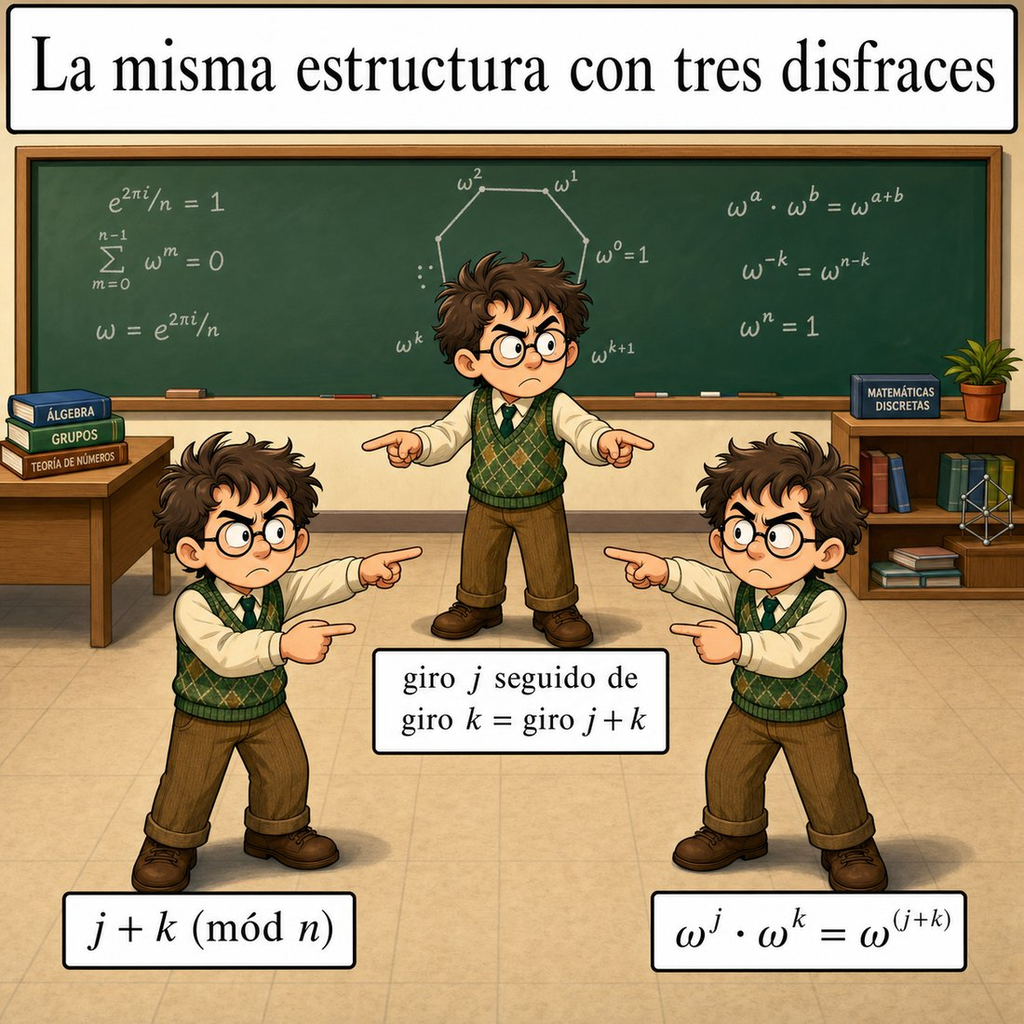

La Observación 2.3.3.1 en versión de bolsillo: residuos módulo $n$, raíces de la unidad y giros del polígono son **el mismo cálculo con tres disfraces** — el diccionario transporta la operación, no solo los nombres.

**Proposición 2.3.4 (la suma nula).** Para $n \ge 2$: $\;\omega_0 + \omega_1 + \cdots + \omega_{n-1} = 0$.

*Demostración.* Sea $S$ la suma. Multiplicando por $\omega$ ($\neq 1$ al ser $n \ge 2$): $\omega S = \omega_1 + \omega_2 + \cdots + \omega_{n-1} + \omega_n$, y $\omega_n = \omega_0$ — la misma lista, reordenada: $\omega S = S$. Entonces $(\omega - 1)S = 0$, y como $\omega \neq 1$ y $\mathbb{C}$ es un cuerpo (Teorema 2.1.6: todo no nulo tiene inverso) no tiene divisores de cero, $S = 0$. *(Geométricamente: el centro de masas del polígono es el origen.)* $\blacksquare$

## 3.3 Las raíces de polinomios reales vienen en parejas

**Proposición 2.3.6.** Sea $p(z) = c_n z^n + \cdots + c_1 z + c_0$ con coeficientes **reales**. Si $z_0$ es raíz, también lo es $\bar{z_0}$.

*Demostración.* Conjugar respeta sumas y productos (Proposición 2.1.4(1)) y fija los reales (Proposición 2.1.4(3)), luego
$$p(\bar{z_0}) = c_n \bar{z_0}^{\,n} + \cdots + c_0 = \overline{c_n z_0^n + \cdots + c_0} = \overline{p(z_0)} = \bar 0 = 0. \;\blacksquare$$

> *(Por eso las soluciones del ejercicio 3 de la S1 salían conjugadas, y por eso $z_2 = \bar{z_0}$ en el Ejemplo 2.3.1.1: $z^3 + 8$ tiene coeficientes reales.)* **Consecuencia anunciada:** las raíces no reales de un polinomio real se agrupan en parejas; combinado con el TFA y la factorización (módulo de Polinomios), dará que *todo polinomio real de grado impar tiene una raíz real*. El recuento fino se completa allí.

## 3.4 El teorema fundamental del álgebra

**Teorema 2.3.7 (TFA — enunciado).** Todo polinomio no constante con coeficientes en $\mathbb{C}$ tiene al menos una raíz en $\mathbb{C}$.

**Qué significa.** Construimos $\mathbb{C}$ (S1) para resolver *una* ecuación; el TFA dice que quedó resuelto **todo**: ninguna ecuación polinómica obliga a ampliar más.

**Definición 2.3.8 (algebraicamente cerrado).** Un cuerpo $K$ es *algebraicamente cerrado* si todo polinomio no constante de $K[x]$ tiene una raíz en $K$. En estos términos, el Teorema 2.3.7 dice exactamente que $\mathbb{C}$ es algebraicamente cerrado. *(Factorizando repetidamente se sigue que sobre $\mathbb{C}$ todo polinomio de grado $n$ tiene exactamente $n$ raíces contadas con multiplicidad; el recuento fino se completa en el módulo de Polinomios.)*

**Qué no dice.** No da ningún método para *encontrar* la raíz — solo garantiza que existe. Nuestros métodos efectivos siguen siendo los de siempre: cuadráticas, raíces $n$-ésimas, y lo que aporte el módulo de Polinomios.

> **Honestidad sobre la prueba.** No se demuestra en este curso, y conviene decir por qué: a pesar del nombre, **toda demostración del TFA usa en algún punto análisis** (la completitud de $\mathbb{R}$ — que a $\mathbb{R}$ “no le faltan puntos”); con álgebra pura no basta. En el módulo de Polinomios lo **usaremos** como herramienta de factorización, citándolo. Para el lector curioso, la ampliación esboza la idea de una prueba.

## Ejercicios

1. ★ Calcula y **dibuja** todas las raíces de: $z^4 = 16$, $\;z^3 = i$, $\;z^6 = 1$. (El polígono es parte de la respuesta.)
2. ★ Resuelve $z^2 + 2z + 5 = 0$ y $z^4 + z^2 - 2 = 0$ (sustitución $u = z^2$; alguna raíz de $u$ será negativa — ahora sabemos qué hacer con ella). Comprueba la Proposición 2.3.6 en ambas.
3. ★ Comprueba por De Moivre que $z_0 = 1 + \sqrt 3\, i$ del Ejemplo 2.3.1.1 cumple $z_0^3 = -8$, y que las tres raíces halladas son las únicas (¿qué parte del Teorema 2.3.1 lo garantiza?).
4. ★ En el hexágono de las raíces sextas de la unidad, señala cuáles son además raíces cúbicas, cuáles cuadradas, y verifica $\omega_2 \cdot \omega_5 = \omega_1$ (Proposición 2.3.3) en el dibujo.
5. Demuestra que el producto de las $n$ raíces de la unidad es $(-1)^{n+1}$. *(Pista: $\omega_0 \omega_1 \cdots \omega_{n-1} = \omega^{0+1+\cdots+(n-1)}$ y la suma de Gauss.)*
6. ¿Cuántas raíces **reales** tiene $z^n = 1$ según la paridad de $n$? Respóndelo desde el dibujo del polígono y desde la fórmula.
7. Un polinomio real de grado 3 tiene raíz $2 - i$. ¿Cuáles son las otras posibilidades para sus raíces? ¿Puede no tener ninguna raíz real? (Usa la Proposición 2.3.6; el cierre formal del argumento llegará en Polinomios.)
8. **(GeoGebra.)** Construye las raíces $n$-ésimas de un $w$ arrastrable con un deslizador en $n$; observa qué les pasa al polígono cuando $w$ gira y cuando $|w|$ crece.

## Ampliación y referencias

> **Ampliación (la idea de una prueba del TFA).** La más visual: para $|z|$ enorme, $p(z) \approx c_n z^n$, de modo que la imagen de una circunferencia grande “da $n$ vueltas” alrededor del origen; para $|z| = 0$ la imagen es el punto $p(0)$. Al encoger la circunferencia de lo grande a lo pequeño, esas vueltas tienen que deshacerse — y no pueden deshacerse sin **cruzar el origen**: ahí hay una raíz. Hacer riguroso “dar vueltas” y “cruzar” es exactamente la parte analítico-topológica que excede el curso. Needham, cap. 7, lo cuenta espléndidamente.

> **Ampliación (raíces de la unidad en el mundo real — perfil Datos).** Las $\omega_k$ son la base de la **transformada discreta de Fourier** y del algoritmo **FFT** que la calcula rápido — procesamiento de señal, compresión de audio e imagen, multiplicación rápida de números enormes. La estructura “los vértices se multiplican como $\mathbb{Z}/n\mathbb{Z}$” (Proposición 2.3.3) tiene nombre técnico — *grupo cíclico* — y teoría propia: Childs, o Aluffi, cap. II.

> **Referencias.** Raíces y polígonos: Hernández; Needham, cap. 1. TFA: enunciado y contexto en Childs; la prueba visual en Needham, cap. 7.